[OHI British Columbia](http://www.ohibc.org/) | [OHI Science](http://ohi-science.org) | [Citation policy](https://github.com/OHI-Science/ohiprep/releases)

# OHIBC: data prep for wild-capture fisheries: spatializing RAM stocks

Compiled on Mon Feb 26 10:19:54 2018 by afflerbach

```r
knitr::opts_chunk$set(fig.width = 6, fig.height = 4, message = FALSE, warning = FALSE)

library(doParallel)
library(sf)
library(foreach)

dir_git <- '~/github/ohibc'
source(file.path(dir_git, 'src/R/common.R'))  ### an OHIBC specific version of common.R
dir_rgn <- file.path(dir_git, 'prep/regions')  ### github: general buffer region shapefiles
dir_anx <- file.path(dir_M, 'git-annex/bcprep')


### goal specific folders and info
dir_spatial  <- file.path(dir_git, 'prep/_spatial')
dir_dfo_data <- file.path(dir_anx, '_raw_data/dfo_khunter')


### support scripts
source(file.path(dir_git, 'src/R/rast_tools.R'))

### bc regions
ohibc_sf <- read_sf(dir_spatial, 'ohibc_rgn', quiet = T) %>%
    st_transform(4326)
```

# 1 Summary

This script collects spatial boundaries for RAM stocks, using stock IDs from the RAM prep script and the boundaries created by Chris Free: https://marine.rutgers.edu/~cfree/ram-legacy-stock-boundary-database/

From this, we generate for each stock a region-by-region proportional area to apportion RAM catch to OHIBC regions.

Where possible we use shapefiles shared with us by DFO.

# 2 Data Source

**Reference**: https://marine.rutgers.edu/~cfree/ram-legacy-stock-boundary-database/

**Downloaded**: 7/5/2017

**Description**: Boundaries for RAM stocks

**Format**: ESRI shapefile format.

# 3 Methods

For each RAM stock identified in the script `1_data_prep_fis_ram.Rmd`, identify the appropriate shapefile for boundaries, either from the Chris Free datasets or from DFO (if there is a difference).

## 3.1 Determine fisheries to analyze

The .zipped set of shapefiles seems to be named according to the RAM `assess_id` field. Copy the relevant set to `git-annex`, in the `fis/v2017/stock_boundaries/ram` folder.

```r
stock_list <- read_csv('output/ram_catch.csv') %>%
  select(stock_id, stock_name, ram_area_name) %>%
  distinct()

ram_spatial_dir <- file.path(dir_anx, '_raw_data/ram_fisheries/d2017/spatial')
boundary_list <- readxl::read_excel(file.path(ram_spatial_dir, 'ramldb_v3.8_stock_boundary_table_v2_formatted.xlsx')) %>%
  filter(stockid %in% stock_list$stock_id)

shp_list <- list.files(file.path(ram_spatial_dir, 'ramldb_boundaries'), full.names = TRUE)

boundary_list <- boundary_list %>%
  select(assessid, stockid, stocklong, zone_col, zones, notes) %>%
  mutate(dir = file.path(ram_spatial_dir, 'ramldb_boundaries'),
         shp = assessid,
         file_exists = file.exists(file.path(dir, shp)))

bc_bounds_dir <- file.path(dir_goal_anx, 'stock_boundaries/ram_files')
unlink(bc_bounds_dir, recursive = TRUE)
dir.create(bc_bounds_dir)
y <- lapply(boundary_list$shp, FUN = function(x) {
  ### x <- boundary_list$shp[1]
  stockname <- x
    # str_replace('-PAC-', '-') %>%
    # str_split('-') %>%
    # unlist() %>% .[2]
  file.copy(from = file.path(ram_spatial_dir, 'ramldb_boundaries', paste0(x, c('.shp', '.prj', '.shx', '.dbf'))),
            to   = file.path(bc_bounds_dir, paste0(stockname, c('.shp', '.prj', '.shx', '.dbf'))))
})
```

## 3.2 Assign relative stock boundary areas to OHIBC regions

For each RAM stock, intersect the RAM boundary polygons (from Chris Free) with the OHIBC regions, then calculate area (in km^2) within each OHIBC region and proportional areas, relative to the overall stock polygon area (including stock extents outside the BC EEZ). The output layer for toolbox use will simply contain OHIBC region, stock ID, and stock-in-region area in km^2.

Note that most species do not actually get fished in the Pacific Offshore region - coastal species and/or demersal species. For these, we will remove area associated with the Pacific Offshore region and recalculate total area based on the continental shelf portion of the polygon instead.

Two exceptions: Halibut and Albacore. These will base the regional catch on the total area of the fishery polygon. The catch for Halibut associated with Pacific Offshore will be dropped.

### 3.2.1 Pacific Hake

The Pacific Hake shapefile from Chris Free’s database is only for Southern California:

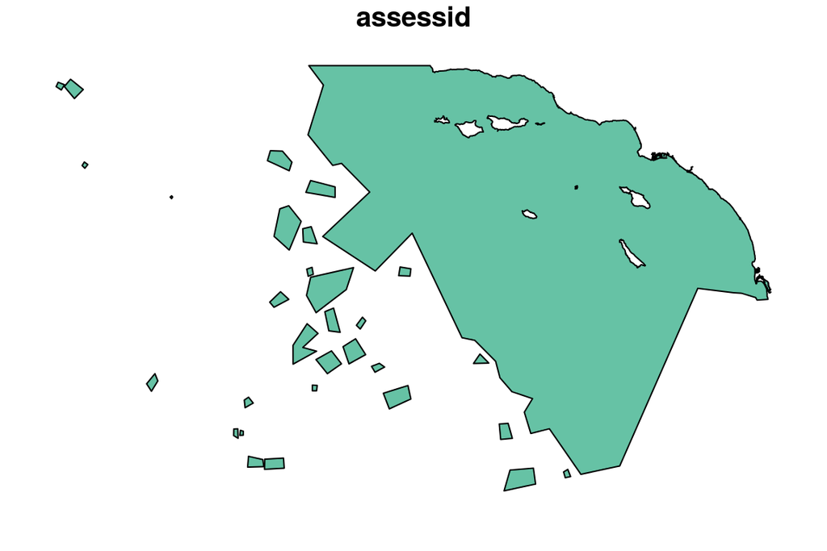

```r
free_hake <- st_read(file.path(dir_anx, "fis/v2017/stock_boundaries/ram_files"), "PFMC-PHAKEPCOAST-1966-2016-WATSON", quiet = T)
plot(free_hake[1])
```

Therefore we can’t use this shapefile. We can use shapefiles provided by DFO. These shapefiles actually have block level data for groundfish fisheries including Pacific Ocean Perch, Halibut, Hake and Sablefish from 1996-2012. So rather than using the proportion of area in each sub-region to apply catch for each stock, we can instead use actual catch proportion in each region for every year.

```r
dfo_shp <- st_read(file.path(dir_anx, "_raw_data/dfo_khunter/fisheries/d2016/groundfish_trawl_old_1996_2012"),"Trawl_1996_BCA", quiet = T) %>%
    st_transform(4326) %>%
    select(HakeWt, SableWt, HalibWt, POPWt, geometry) %>% #grab hake, sablefish, halibut and ocean perch catch plus geometries
    mutate(year = 1996) %>%
    gather(key = species, value = catch, -geometry, -year)

for (yr in 1997:2012) {

  out <- st_read(file.path(dir_anx, "_raw_data/dfo_khunter/fisheries/d2016/groundfish_trawl_old_1996_2012"), paste0("Trawl_",yr,"_BCA"), quiet = T) %>%
    st_transform(4326) %>%
    select(HakeWt, SableWt, HalibWt, POPWt, geometry) %>% #grab hake, sablefish, halibut and ocean perch catch plus geometries
    mutate(year = yr) %>%
    gather(key = species, value = catch, -geometry, -year)

  dfo_shp <-rbind(out, dfo_shp)
}
```

Now we have all the data we need in long format (year, species, catch). Next we need to calculate total catch within each year, and then the proportion of catch in each cell by species. This is a great time to use purrr???

```r
#join shapefile with regions so we can look at catch prop within each sub region
join <- dfo_shp %>%
  st_join(ohibc_sf)

catch_prop <- join %>%
  group_by(year, species) %>%
  mutate(total_catch = sum(catch)) %>%
  ungroup() %>%
  mutate(catch_prop = catch / total_catch) %>%
  filter(catch > 0) %>% #remove areas of zero catch
  group_by(year, species, rgn_id, rgn_name, rgn_code) %>%
  summarize(rgn_catch_prop = sum(catch_prop)) %>%
  as.data.frame() %>%
  mutate(species = case_when(
    species == "HakeWt" ~ "Hake",
    species == "HalibWt" ~ "Halibut",
    species == "POPWt" ~ "Pacific Ocean Perch",
    species == "SableWt" ~ "Sablefish"
  )) %>%
  select(year, species, rgn_id, rgn_name, rgn_catch_prop)

write_csv(catch_prop, "data/2_dfo_groundfish_catch_prop.csv")
```

Now we intersect the RAM shapefiles with our BC regions. First we want to only grab those shapefiles we need, which would be the assessed stocks but not including those that were included in the groundfish shapefile from DFO.

```r
# read in unique stocks from RAM, filtered for stocks that have at least B/Bmsy
ts <- read_csv("data/1_bc_stocks_ts_ram.csv") %>%
  filter(metric == "BdivBmsypref",
         !str_detect(stockid, paste(c("PHAL", "SABLE", "HAKE", "PERCH"),collapse = '|'))) %>%
  select(stockid) %>%
  distinct() %>%
  .$stockid


ram_bounds_dir <- file.path(dir_anx, 'fis/v2017/stock_boundaries/ram_files')

## get the full list of files. We can remove the ones we are using for Hake, halibut, sablefish and ocean perch.
shp_list <- list.files(ram_bounds_dir, pattern = '.shp$', full.names = FALSE) %>%
    str_replace('.shp$', '')

## removing those shapefiles
  shps_list <- str_detect(shp_list, paste0(ts, collapse = '|'))

  shp_list <- shp_list[shps_list]

  #function to intersect shapefiles
  intsx_ram <- function(ram_layer) {
    ### ram_layer <- shp_list[40]

    ram_sf <- read_sf(ram_bounds_dir, ram_layer) %>%
      mutate(tot_area_m2 = st_area(geometry))

    intsx_sf <- st_intersection(ohibc_sf, ram_sf) %>%
      select(rgn_name, rgn_id, assessid, stockid, tot_area_m2)

    if(nrow(intsx_sf) > 0) {
      intsx_sf <- intsx_sf %>%
        mutate(area_m2 = st_area(geometry))
    }
      if(!str_detect(ram_layer, 'ALBA')) {
        ### subtract pacific offshore and readjust total area
        intsx_sf <- intsx_sf %>%
          filter(rgn_id != 7) %>%
          mutate(tot_area_m2 = sum(area_m2))
      }

      intsx_df <- intsx_sf %>%
        as.data.frame() %>%
        select(-geometry)

      return(intsx_df)

  }

   ram_ohibc_all <- map_df(shp_list, intsx_ram) %>%
    group_by(stockid) %>%
    mutate(area_km2 = area_m2 / 1e6,
           a_prop   = area_m2 / tot_area_m2,
           tot_area_km2 = tot_area_m2 / 1e6) %>%
    select(-area_m2, -tot_area_m2)


write_csv(ram_ohibc_all, "data/2_ram_stock_to_ohibc_areas.csv")
```

```r
ram_ohibc_all <- read_csv("data/2_ram_stock_to_ohibc_areas.csv") %>%
  select(rgn_id, stockid, area_km2, a_prop)

DT::datatable(ram_ohibc_all)
```

|  | rgn_id | stockid | area_km2 | a_prop |
| --- | --- | --- | --- | --- |
| 1 | 5 | CROCKWCVANISOGQCI | 22419.6137210797 | 0.181429470436531 |
| 2 | 6 | CROCKWCVANISOGQCI | 8024.81253180234 | 0.0649403467031376 |
| 3 | 1 | CROCKWCVANISOGQCI | 16869.7709445147 | 0.136517678088768 |
| 4 | 2 | CROCKWCVANISOGQCI | 40254.0334493919 | 0.325753514869473 |
| 5 | 3 | CROCKWCVANISOGQCI | 20205.2842628225 | 0.163510133110666 |
| 6 | 4 | CROCKWCVANISOGQCI | 12617.0196326505 | 0.102102525891729 |
| 7 | 8 | CROCKWCVANISOGQCI | 3181.52719135119 | 0.0257463308996955 |
| 8 | 5 | BOCACCBCW | 22419.6137210797 | 0.181429470436531 |
| 9 | 6 | BOCACCBCW | 8024.81253180234 | 0.0649403467031376 |
| 10 | 1 | BOCACCBCW | 16869.7709445147 | 0.136517678088768 |

[output cut: 33 more lines]

```r
 write_csv(ram_ohibc_all, 'output/ram_stock_area.csv')
```

## 3.3 Plot maps

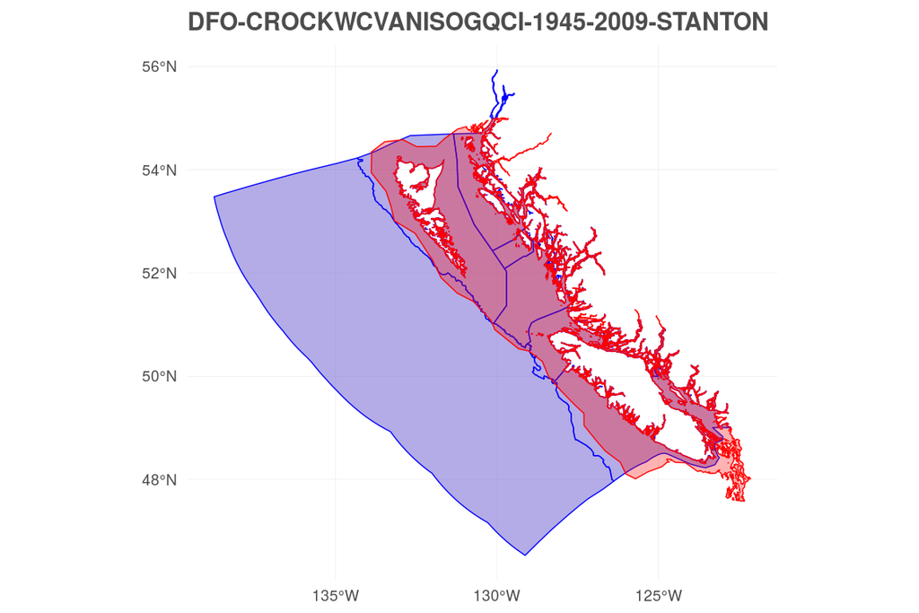

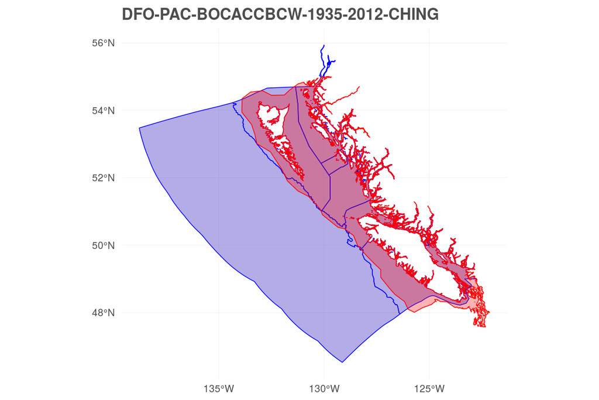

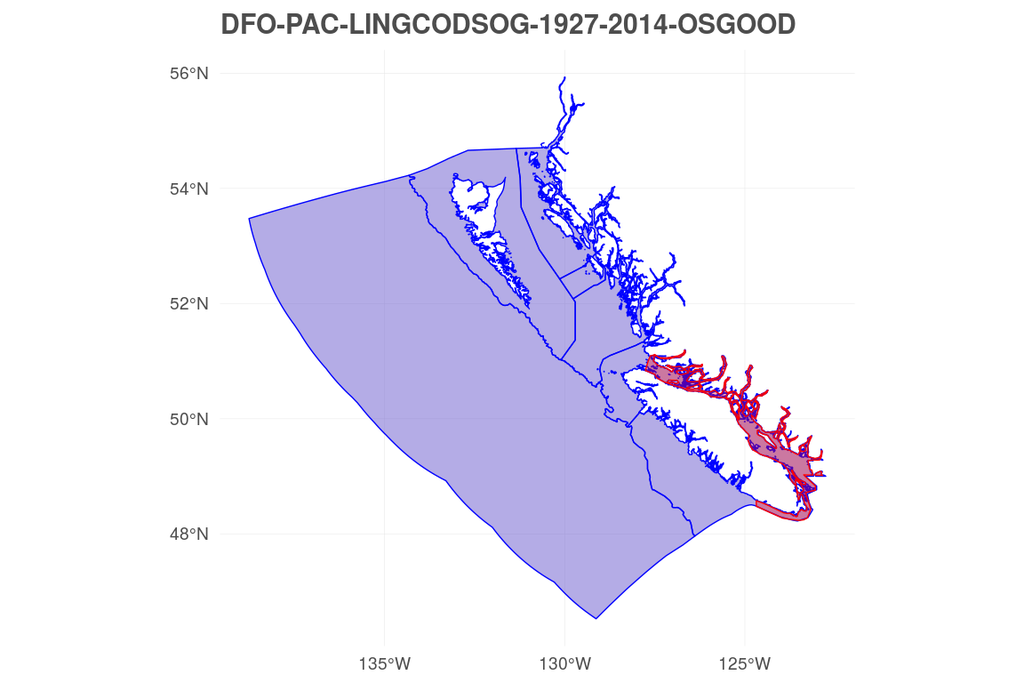

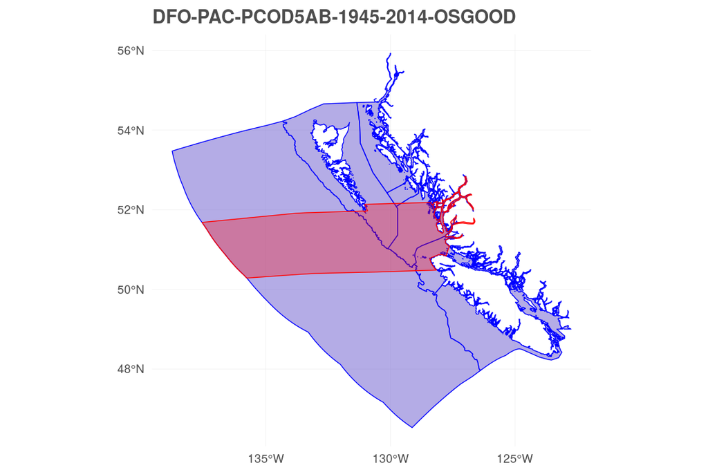

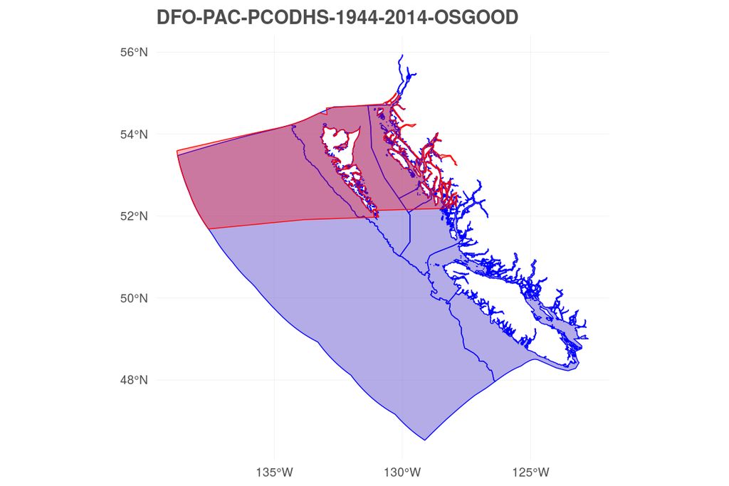

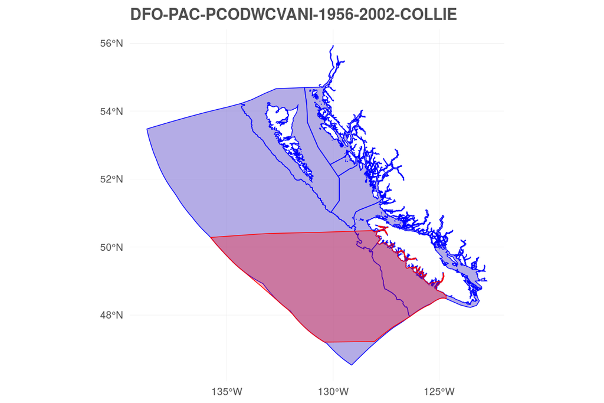

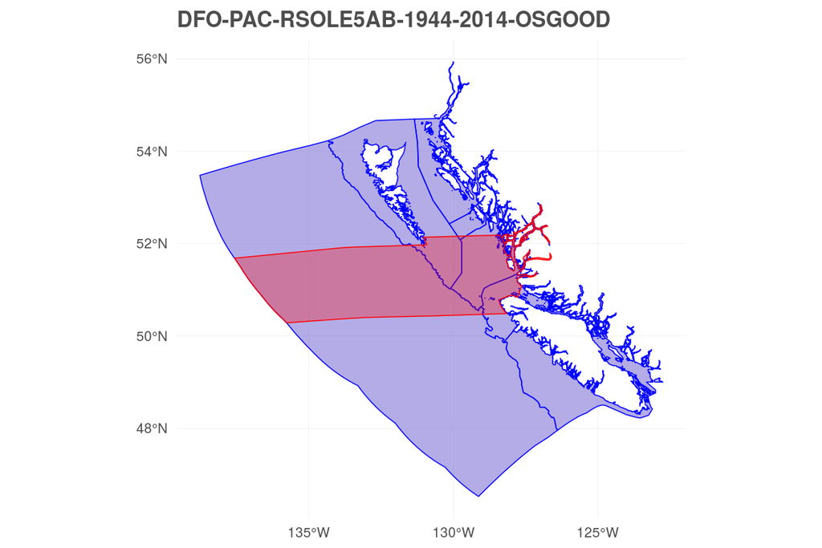

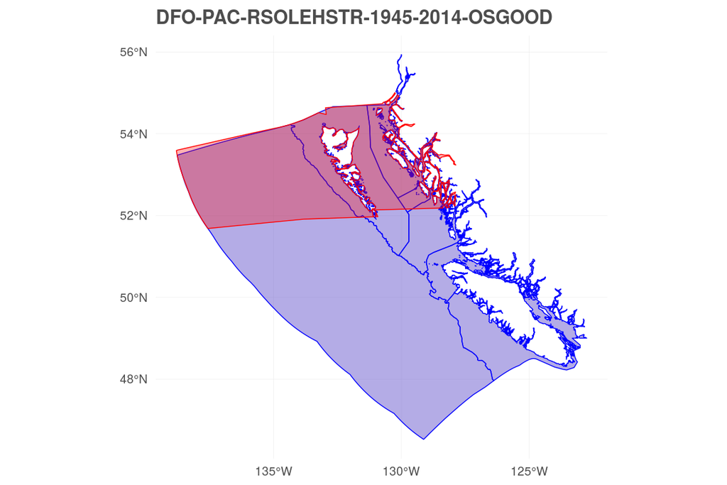

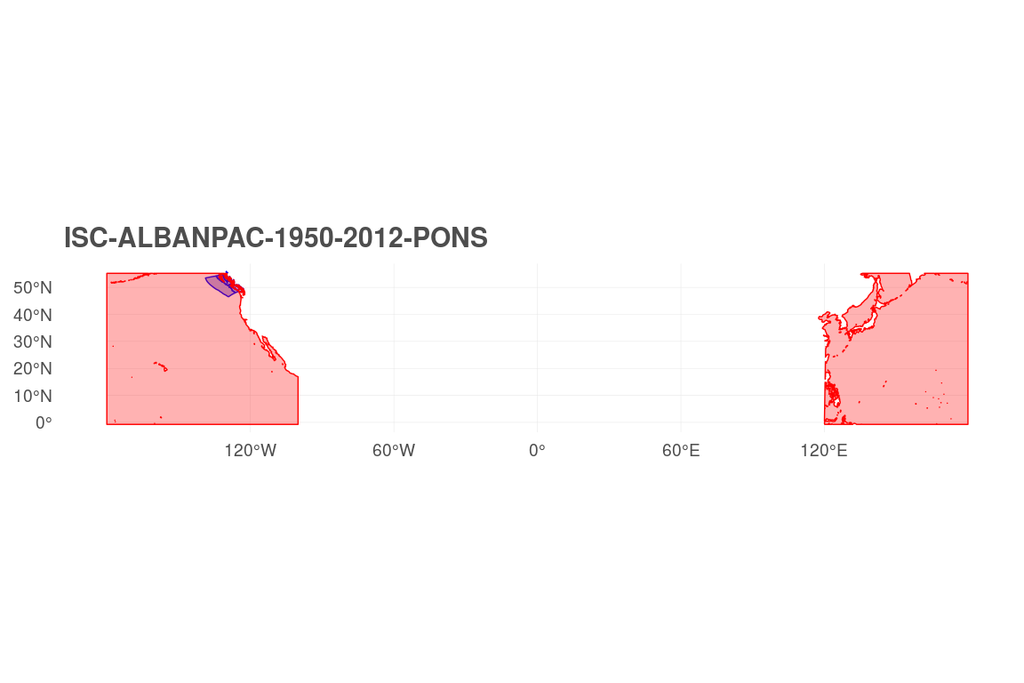

```r
for(ram_layer in shp_list) {
  ### ram_layer <- shp_list[10]

  message('Generating map for ', ram_layer)

  ram_sf <- read_sf(ram_bounds_dir, ram_layer)

  ram_map <- ggplot() +
    ggtheme_plot() +
    geom_sf(data = ohibc_sf, alpha = .5, fill = 'slateblue', color = 'blue', size = .25) +
    geom_sf(data = ram_sf, alpha = .3, fill = 'red', color = 'red', size = .25) +
    labs(title = ram_layer)

  print(ram_map)

}
```